# Reproducible Research Course Project 1

Load the Data

```r
# Code for reading the data
library(knitr)
getwd()
```

```
## [1] "C:/Users/robert/Documents/data/ReproducibleResearch/CourseProject2/repdata_data_activity"
```

```r
setwd("C:/users/robert/documents/data/ReproducibleResearch/CourseProject2/repdata_data_activity")
activity<-read.csv("activity.csv")
```

The total number of steps per day

```r
##The total number of steps taken each day
bydaySum<-(aggregate(steps~date,data=activity,FUN=sum))
bydaySum
```

```
##          date steps
## 1  2012-10-02   126
## 2  2012-10-03 11352
## 3  2012-10-04 12116
## 4  2012-10-05 13294
## 5  2012-10-06 15420
## 6  2012-10-07 11015
## 7  2012-10-09 12811
## 8  2012-10-10  9900
## 9  2012-10-11 10304
## 10 2012-10-12 17382
## 11 2012-10-13 12426
## 12 2012-10-14 15098
## 13 2012-10-15 10139
## 14 2012-10-16 15084
```

[output cut: 39 more lines]

A histogram of the total number of steps per day

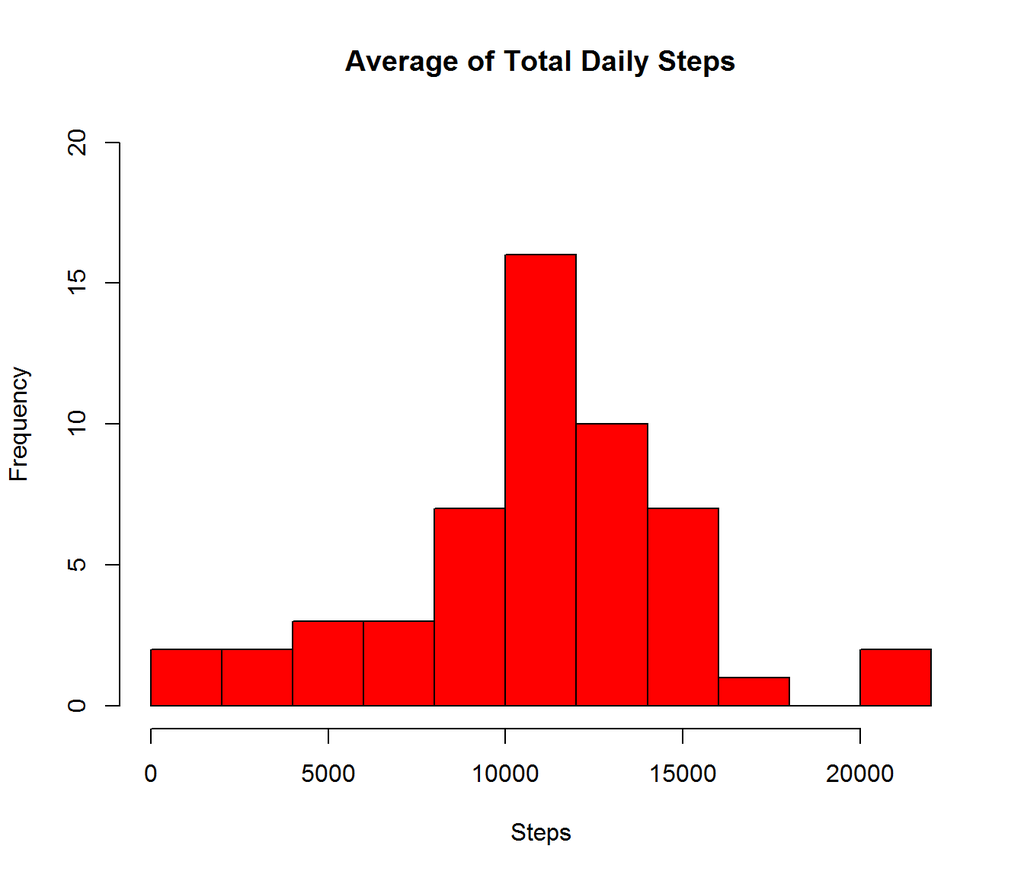

```r
##Histogram of total number of steps taken each day
hist(bydaySum$steps, breaks=10, col="red", ylim = c(0,20), main="Average of Total Daily Steps", xlab="Steps")
```

The mean and median of the total number of steps taken per day

```r
#the mean and median of the total number of steps taken per day
mean(bydaySum$steps)
```

```
## [1] 10766.19
```

```r
median(bydaySum$steps)
```

```
## [1] 10765
```

The average daily activity pattern

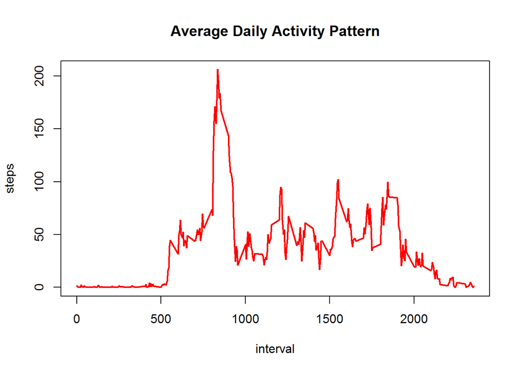

```r
#plot total of daily average number of steps taken per interval
int<-aggregate(steps~interval,data=activity, FUN=mean)
intPlot<-with(int,plot(interval, steps, type="l", main="Average Daily Activity Pattern", col="red", lwd=2))
```

The five-minute interval that contains the maximum number of steps

```r
int[which.max(int$steps), ]
```

```
##     interval    steps
## 104      835 206.1698
```

Imputing Missing Values

The total number of missing values in the dataset (i.e. the total number of rows with NAs)

```r
sum(is.na(activity))
```

```
## [1] 2304
```

```r
#create a new dataset with the NA values filled in
activity2<-activity
naValues<-is.na(activity2$steps)
interval_mean<-tapply(activity2$steps, activity2$interval, mean, na.rm=TRUE, simplify=TRUE)
activity2$steps[naValues]<-interval_mean[as.character(activity2$interval[naValues])]
names(activity2)
```

```
## [1] "steps"    "date"     "interval"
```

```r
sum(is.na(activity2))
```

```
## [1] 0
```

Histogram of the total number of step taken each day

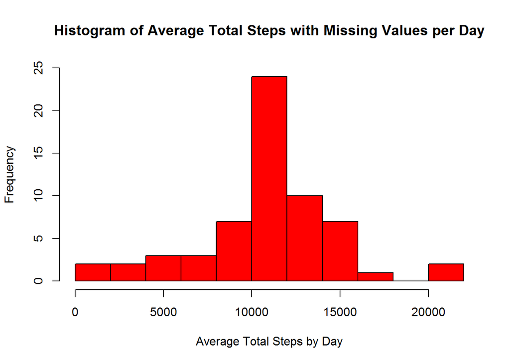

```r
bydaySum2<-(aggregate(steps~date,data=activity2,FUN=sum))
hist(bydaySum2$steps, breaks=15, xlab="Average Total Steps by Day", main="Histogram of Average Total Steps with Missing Values per Day", ylim=c(0, 25), col="red")
```

The mean and median total number of steps taken per day

```r
mean(bydaySum2$steps)
```

```
## [1] 10766.19
```

```r
median(bydaySum2$steps)
```

```
## [1] 10766.19
```

The mean and median do not differ. The histogram is different.

The impact of imputing missing data on the estimates of the total daily number of steps?

```r
summary(bydaySum)
```

```
##          date        steps
##  2012-10-02: 1   Min.   :   41
##  2012-10-03: 1   1st Qu.: 8841
##  2012-10-04: 1   Median :10765
##  2012-10-05: 1   Mean   :10766
##  2012-10-06: 1   3rd Qu.:13294
##  2012-10-07: 1   Max.   :21194
##  (Other)   :47
```

```r
summary(bydaySum2)
```

```
##          date        steps
##  2012-10-01: 1   Min.   :   41
##  2012-10-02: 1   1st Qu.: 9819
##  2012-10-03: 1   Median :10766
##  2012-10-04: 1   Mean   :10766
##  2012-10-05: 1   3rd Qu.:12811
##  2012-10-06: 1   Max.   :21194
##  (Other)   :55
```

Are there any difference in activity patterns between weekdays and weekends?

```r
#create a new factor variable in the dataset with two levels-"weekday" and "weekend"
activity2$date<-as.Date(activity2$date)
weekdays1<-c("Monday", "Tuesday", "Wednesday", "Thursday", "Friday")

activity2$weekDay<-factor((weekdays(activity2$date) %in% weekdays1),levels=c(FALSE, TRUE), labels = c("Weekend", "Weekday"))
```

A panel plot containing a time series plot of the 5-minute interval and the average number of steps taken, averaged across all weekdays or weekenend days

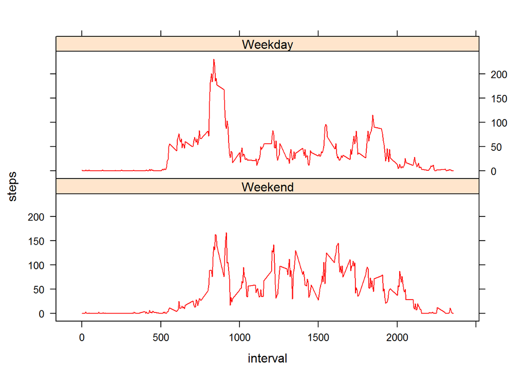

```r
library(lattice)
int2<-aggregate(steps~weekDay+interval,data=activity2, FUN=mean)
xyplot(steps~interval|weekDay, data=int2, layout=c(1,2), type="l", col="red")
```